# The Central Limit Theorem

M5 ICA2

# Introduction

The **Central Limit Theorem**, usually abbreviated CLT, is one of the most important results in statistics. It states that the distribution of sample means, computed for simple random samples taken from a population with mean $\mu$, is normal (that is, bell shaped and symmetric), with center at the population mean, $\mu$. This is true, no matter what the distribution of the population looks like, provided the samples are large enough!

If the original population is itself normal (for example, biological data, like height and weight, have this kind of distribution) then the result holds even for small samples (sizes less than 30). On the hard, if the distribution of the population is heavily skewed (for example, income data or population size of cities) then the samples need to be larger, at least 30.

The fact that the sample means have a predictable distribution has important consequences for applications. Using this fact and the knowledge we have about normal distributions we can construct intervals of plausible values for population parameters, called **confidence intervals**, and we can set up statistical tests, called **hypothesis tests**, to see if certain values are plausible for the population parameters. More on this in the lectures to follow.

In this assignment you will check the Central Limit Theorem by simulating taking repeated samples from a “population” and plotting the sample means. The “population”, in this case, will be represented by a vector of values from a data set.

# The `nc` data set

In 2004, the state of North Carolina released a large data set containing information on births recorded in this state. This data set is useful to researchers studying the relation between habits and practices of expectant mothers and the birth of their children. A random sample of observations from this data set is stored the file `nc` which is part of the package `statsr`.

Load the `tidyverse` and `statsr` packages and take a look at the `nc` data set. Inspect also the documentation page of `nc` by running the `?nc` command in the console.

```r
install.packages('statsr')
```

[output not shown]

```r
library(tidyverse)
library(statsr)

nc
```

| fage | mage | mature | weeks | premie | visits | marital | gained | weight | lowbirthweight | gender | habit | whitemom |
| --- | --- | --- | --- | --- | --- | --- | --- | --- | --- | --- | --- | --- |
| NA | 13 | younger mom | 39 | full term | 10 | married | 38 | 7.63 | not low | male | nonsmoker | not white |
| NA | 14 | younger mom | 42 | full term | 15 | married | 20 | 7.88 | not low | male | nonsmoker | not white |
| 19 | 15 | younger mom | 37 | full term | 11 | married | 38 | 6.63 | not low | female | nonsmoker | white |
| 21 | 15 | younger mom | 41 | full term | 6 | married | 34 | 8.00 | not low | male | nonsmoker | white |
| NA | 15 | younger mom | 39 | full term | 9 | married | 27 | 6.38 | not low | female | nonsmoker | not white |
| NA | 15 | younger mom | 38 | full term | 19 | married | 22 | 5.38 | low | male | nonsmoker | not white |
| 18 | 15 | younger mom | 37 | full term | 12 | married | 76 | 8.44 | not low | male | nonsmoker | not white |
| 17 | 15 | younger mom | 35 | premie | 5 | married | 15 | 4.69 | low | male | nonsmoker | not white |
| NA | 16 | younger mom | 38 | full term | 9 | married | NA | 8.81 | not low | male | nonsmoker | white |
| 20 | 16 | younger mom | 37 | full term | 13 | married | 52 | 6.94 | not low | female | nonsmoker | white |

[output cut: 990 more lines]

We will work with the variables `weight` and `premie`, which will be our “populations”.

# The CLT for means

The variable `weight` records the weight (in pounds) of the baby at birth.

1. Compute the mean and standard deviation of the `weight` variable.

```r
nc_weight <- nc %>%
  select(weight) %>%
  summarise(mean_w = mean(weight, na.rm =TRUE), sd_w = sd(weight,na.rm = TRUE))

nc_weight
```

| mean_w | sd_w |
| --- | --- |
| 7.101 | 1.50886 |

2. Plot the histogram of the `weight` variable. Hint: use `binwidth = 0.5`.

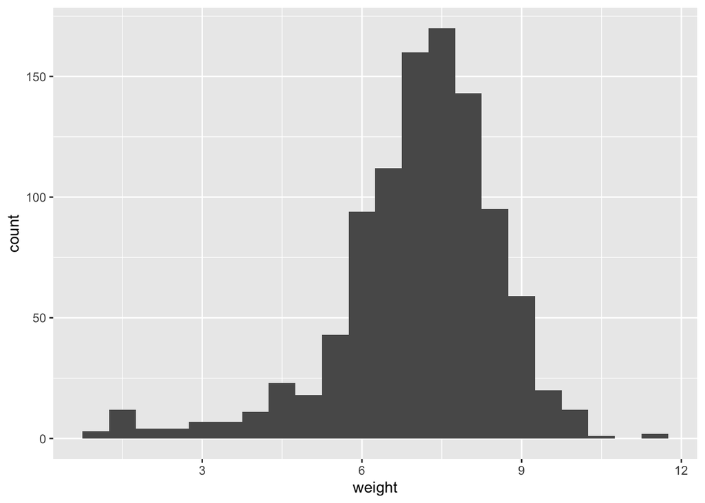

```r
ggplot(nc, aes(weight)) +
  geom_histogram(binwidth = 0.5)
```

```r
size_05 <- replicate(5000, mean(sample(nc$weight, 5,replace = TRUE)))

head(size_05)
```

```
[1] 6.526 7.602 4.826 7.200 6.626 7.774
```

5. Do the same for samples of size 15 and 45 and store the average weights in the vectors `size_15` and `size_45`. Create a data frame `samples1` with the 3 vectors `size_05`, `size_15`, `size_45`.

```r
size_15 <- replicate(5000, mean(sample(nc$weight, 15,replace = TRUE)))

size_45 <- replicate(5000, mean(sample(nc$weight, 45,replace = TRUE)))

samples1 <- data.frame(size_05,size_15,size_45)

samples1
```

| size_05 | size_15 | size_45 |
| --- | --- | --- |
| 6.526 | 7.273333 | 7.236444 |
| 7.602 | 6.984667 | 7.344444 |
| 4.826 | 7.450000 | 7.054667 |
| 7.200 | 6.938667 | 7.205556 |
| 6.626 | 6.563333 | 6.958000 |
| 7.774 | 7.819333 | 7.449111 |
| 6.828 | 7.176000 | 7.154889 |
| 5.852 | 7.159333 | 6.866000 |
| 6.886 | 7.088667 | 7.039333 |
| 7.964 | 7.021333 | 7.143333 |

[output cut: 4990 more lines]

6. Change the format of the `samples1` data frame from wide format to long format using `pivot_longer`. Put the column names into a variable `sample_size` and the values of the three columns into a variable `sample_mean`.

```r
samples_long <- samples1 %>%
  pivot_longer(cols = 1:3, names_to = "sample_size", values_to = "sample_mean")
```

7. Plot the histogram of the `sample_mean` variable, for each of the three sample size: 5, 15, and 45. Hint: `facet_grid`.

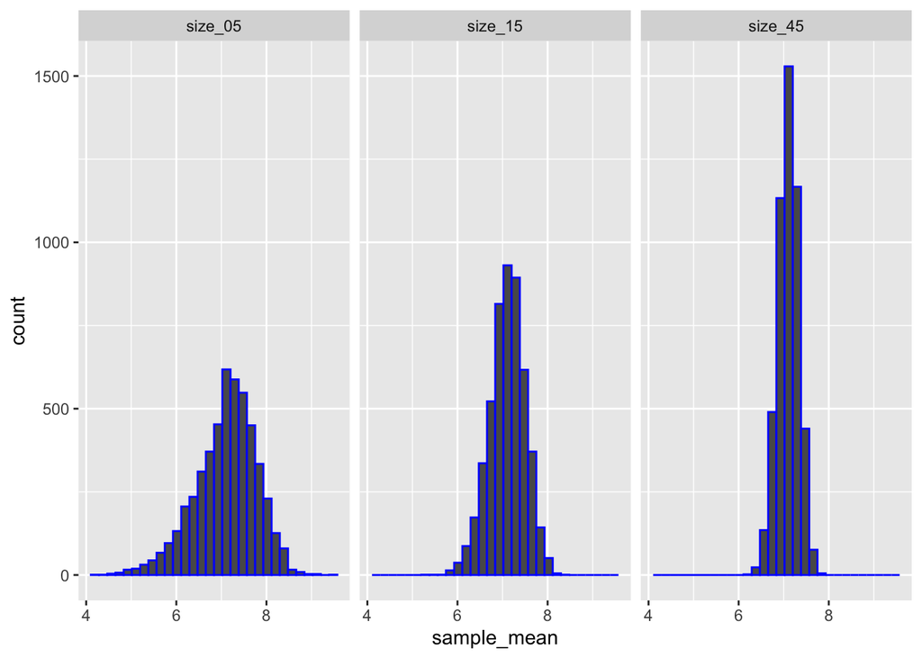

```r
ggplot(samples_long, aes(x = sample_mean)) +
  geom_histogram(bins = 30, color='blue') +
  facet_grid(~ sample_size)
```

8. Calculate the center (mean) and the spread (standard deviation) of each of the three distributions. Hint: `group_by` and `summarize`

```r
samples_long %>%
  group_by(sample_size) %>%
  summarize(mean_s = mean(sample_mean), sd_s = sd(sample_mean))
```

| sample_size | mean_s | sd_s |
| --- | --- | --- |
| size_05 | 7.101720 | 0.6790117 |
| size_15 | 7.101715 | 0.3929881 |
| size_45 | 7.099220 | 0.2291366 |

# The CLT for proportions

Let’s look now at a categorical variable. The `premie` variable records whether the birth was classified as premature (premie) or full-term.

10. Display the table of counts of the `premie` variable. Hint: `group_by` and `count()`.

```r
premie_sort <- nc %>%
  group_by(premie) %>%
  count()
premie_sort
```

| premie | n |
| --- | --- |
| full term | 846 |
| premie | 152 |
| NA | 2 |

11. Create a bar chart to display the distribution of the `premie` variable. Hint: filter out the NAs and use `width = 0.5` inside the `geom_bar()` function.

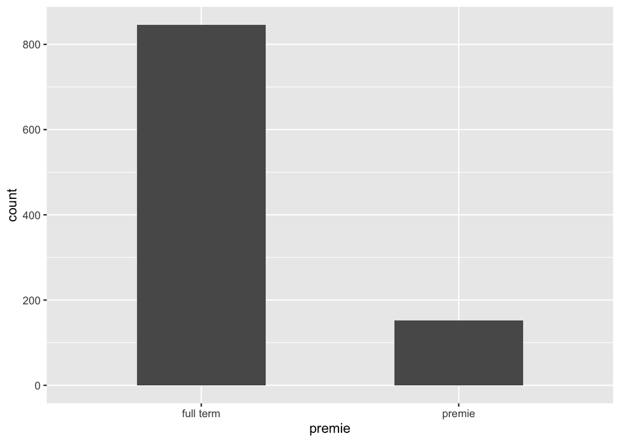

```r
ggplot(nc %>% filter(!is.na(premie)) , aes(x = premie)) +
  geom_bar(width = 0.5)
```

12. Using the `premie` vector, create a new vector `premature` with only two values: 1 if the birth was premature and 0 if the birth was full-term. Hint: `ifelse()`

```r
premature <- ifelse(nc$premie == "premie", 1, 0)
```

13. What is the proportion of premature births in the data-set?

```r
sum(premature == 1, na.rm = TRUE)
```

```
[1] 152
```

14. Take repeated samples (5000 samples) of size 5 from the `premature` variable and find the proportion of premature births in each sample. Store the proportions in a vector called `size_05`.

```r
size_05 <- replicate(5000, mean(sample(premature, 5,replace = TRUE)))
```

15. Do the same for samples of size 15 and 75 and store the proportion of pre-mature births in the vectors `size_15` and `size_75`. Create a data frame `samples3` with the 3 vectors: `size_05`, `size_15`, `size_75`.

```r
size_15 <- replicate(5000, mean(sample(premature, 15,replace = TRUE)))
size_75 <- replicate(5000, mean(sample(premature, 75,replace = TRUE)))

samples3 <- data.frame(size_05,size_15,size_75)
```

16. Change the format of the `samples3` data frame from wide format to long format using `pivot_longer`. Put the column names into a variable `sample_size` and the values of the three columns into a variable `sample_proportion`. Call the new data frame `sample4`

```r
samples_long <- samples3 %>%
  pivot_longer(cols = 1:3, names_to = "sample_size", values_to = "sample_proportion")
```

17. Plot the histogram of the `sample_proportion` variable, for each of the three sample size: 5, 15, and 75.

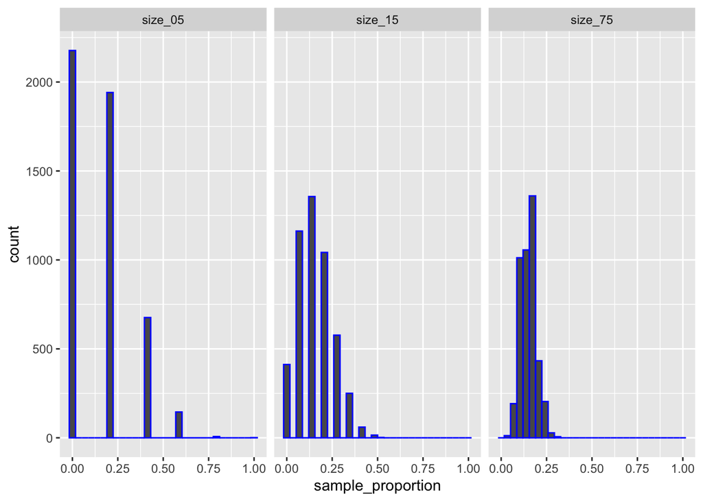

```r
ggplot(samples_long, aes(x = sample_proportion)) +
  geom_histogram(bins = 30, color='blue') +
  facet_grid(~ sample_size)
```

18. Calculate the center (mean) and the spread (standard deviation) of each of the three distributions.

```r
samples_long %>%
  group_by(sample_size) %>%
  summarize(mean_s = mean(sample_proportion), sd_s = sd(sample_proportion))
```

| sample_size | mean_s | sd_s |
| --- | --- | --- |
| size_05 | NA | NA |
| size_15 | NA | NA |
| size_75 | NA | NA |

# Conclusion

As the two examples show, the Central Limit Theorem guarantees that the **sample statistics** (sample means or sample proportions) **have a normal distribution when the samples are large enough**. Moreover, **the sampling distributions** (the distribution of sample statistics) **are centered at the population parameter**.

These facts are the key for understanding statistical inference, which deals with testing a hypothesized value of the population mean or the population proportion based on a random sample, and with constructing confidence intervals for the population mean or the population proportion.